# A Multi-Metric Analysis of Ecosystem Recovery

Gabriela Albuquerque Galvão

### Packages

- tidyverse
- ggplot2
- vegan
- ade4
- FD
- knitr
- kableExtra

## Executive summary

> **The core question:** Can a single metric tell the full story of a complex system, or does it hide what matters most?

This project analyzes biodiversity data collected from areas impacted by the São Francisco River transposition project (Caatinga biome, Brazil). Using a **multi-metric analytical framework**, I demonstrate that surface-level indicators can be misleading, that is: a finding directly applicable to any domain where data-driven decisions depend on choosing the right KPI.

**Key result:** Taxonomic richness showed *no significant difference* between groups. Functional diversity revealed *highly significant differences* (p < 0.01). Same data. Different question. Different answer.

## 1. The Problem

Environmental restoration projects, like business interventions, require monitoring tools to evaluate their effectiveness. But which metric do you trust?

This dataset covers **four distinct landscape conditions**, analogous to experimental groups in an A/B test:

| Group | Description |
| --- | --- |
| **Control** | Non-impacted reference areas |
| **Degraded** | Impacted areas of São Francisco river transposition |
| **Restoration 1** | Direct seeding technique |
| **Restoration 2** | Combined restoration techniques |

The goal: determine whether restoration is working, but also and *how* to measure “working” in an ecology context.

## 2. Data

```r
dataset_cmm <- read.csv("comunidade.csv",
                       sep = ";",
                       row.names = 1)
kable(head(dataset_cmm[, 1:10]), caption = "Community matrix (first 10 columns shown)") %>%
  kable_styling(full_width = FALSE, bootstrap_options = c("striped", "hover"))
```

Community matrix (first 10 columns shown)

|  | Grupo | area_ha | metodo | ndv100 | ndv140 | ndv200 | ndv280 | ndv400 | ndv560 | ndv800 |
| --- | --- | --- | --- | --- | --- | --- | --- | --- | --- | --- |
| A | RE1 | 0.74 | SBD | 0.0019691 | 0.0032223 | 0.0032894 | 0.0036461 | 0.0040279 | 0.0043127 | 0.0038888 |
| B | RE1 | 0.56 | SBD | 0.0008947 | 0.0014306 | 0.0015269 | 0.0022231 | 0.0045083 | 0.0049512 | 0.0053957 |
| C | RE2 | 0.16 | SBD_NARN | 0.0028598 | 0.0033867 | 0.0038416 | 0.0038198 | 0.0035608 | 0.0036512 | 0.0051698 |
| D | RE2 | 1.23 | SBD_SAD_NARN | 0.0027853 | 0.0036848 | 0.0042338 | 0.0037840 | 0.0037158 | 0.0038561 | 0.0060315 |
| E | RE2 | 6.08 | SBD_SAD_NARN | 0.0002781 | 0.0008991 | 0.0050403 | 0.0089760 | 0.0109476 | 0.0093288 | 0.0078607 |
| F | RE1 | 0.51 | SBD | 0.0029246 | 0.0031586 | 0.0044124 | 0.0052390 | 0.0070767 | 0.0063528 | 0.0055461 |

```r
traits <- read.csv("traits.csv",
                   sep = ";",
                   row.names = 1,
                   fileEncoding = "Latin1")
kable(head(traits), caption = "Species trait matrix") %>%
  kable_styling(full_width = FALSE, bootstrap_options = c("striped", "hover"))
```

Species trait matrix

|  | h_max | h_min | leaf_min | leaf_max | semente.cm. | dispersal | life_span | type | Floral_rewarning | Pollination_systems | leaf_tipe | filotaxia | nativas |
| --- | --- | --- | --- | --- | --- | --- | --- | --- | --- | --- | --- | --- | --- |
| Acalypha_poiretii | 700 | 300 | 17 | 35 | 0.618 | autocoria | annual | erva | NA | wind | simples | alternas | nativa |
| Bernardia_sidoides | 600 | 30 | NA | NA | 0.672214 | Zoocoria | annual | erva | NA | NA | simples | verticilada | nativa |
| Cnidoscolus_urens | 2200 | 500 | 45 | 255 | 2.344512 | Zoocoria | perennial | subarbusto | nectar | generalista | simples | alternas | nativa |
| Jatropha_mollissima | 3000 | 1000 | 30 | 150 | 3.173751152 | Zoocoria | annual | arbusto | nectar | himenoptera | simples | alternas | nativa |
| Euphorbia_hyssopifolia | 600 | 400 | 40 | 100 | 0.1372 | autocoria | perennial | erva | nectar | himenoptera | simples | opostas | nativa |
| Euphorbia_hirta | 600 | 100 | 15 | 20 | 0.772 | autocoria | annual | erva | nectar | himenoptera | simples | opostas | nativa |

```r
# Species abundance matrix
cmm_table <- dataset_cmm %>%
  dplyr::select(21:126)

# Treatment groups
treatments <- dataset_cmm %>%
  dplyr::pull(Grupo)
```

**Dataset dimensions:** 32 sampling units × 106 species, plus 13 functional trait variables per species.

## 3. Data Preparation & Feature Engineering

Standardization is essential before multivariate analysis. Here I apply the **Hellinger transformation**, it down-weights highly abundant species and normalizes sampling effort, making samples comparable regardless of total seed counts.

> *Business analogy: this may be equivalent to normalizing revenue by market size before comparing regions.*

```r
# Hellinger transformation
cmm_hell <- vegan::decostand(cmm_table, method = "hellinger")

# Feature 1: taxonomic richness (species count per sample)
richness <- rowSums(cmm_table > 0)

dados <- data.frame(
  richness = richness,
  group = treatments
) %>%
  mutate(
    group = case_when(
      group == "N"   ~ "Degraded",
      group == "P"   ~ "Control",
      group == "RE1" ~ "Restoration 1",
      group == "RE2" ~ "Restoration 2"
    ),
    group = factor(group, levels = c("Control", "Degraded", "Restoration 1", "Restoration 2"))
  )
```

## 4. Metric 1: Taxonomic richness (the obvious KPI)

The first and most intuitive metric: how many species are present in each condition?

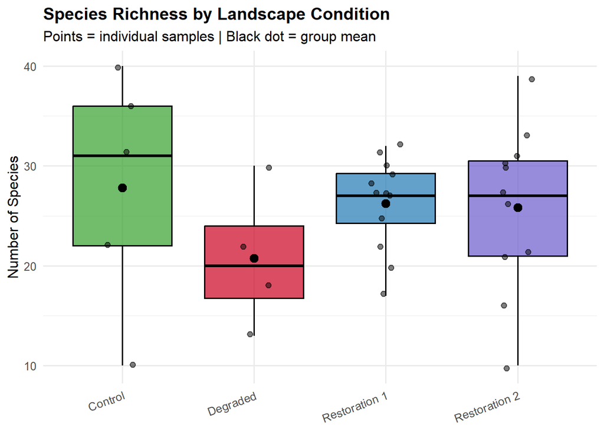

```r
ggplot(dados, aes(x = group, y = richness, fill = group)) +
  geom_boxplot(alpha = 0.7, outlier.shape = NA, color = "black") +
  geom_jitter(width = 0.12, alpha = 0.5, size = 2) +
  stat_summary(fun = mean, geom = "point", size = 3, color = "black") +
  scale_fill_manual(values = c(
    "Control"       = "#33a02c",
    "Degraded"      = "#ca0020",
    "Restoration 1" = "#1f78b4",
    "Restoration 2" = "#6A5ACD"
  )) +
  theme_minimal(base_size = 12) +
  labs(
    title = "Species Richness by Landscape Condition",
    subtitle = "Points = individual samples | Black dot = group mean",
    x = NULL, y = "Number of Species"
  ) +
  theme(legend.position = "none", plot.title = element_text(face = "bold"),
        axis.text.x = element_text(angle = 20, hjust = 1))
```

```r
anova_richness <- aov(richness ~ group, data = dados)
shapiro.test(residuals(anova_richness))
```

```
##
##  Shapiro-Wilk normality test
##
## data:  residuals(anova_richness)
## W = 0.97035, p-value = 0.509
```

```r
bartlett.test(richness ~ group, data = dados)
```

```
##
##  Bartlett test of homogeneity of variances
##
## data:  richness by group
## Bartlett's K-squared = 6.2497, df = 3, p-value = 0.1001
```

```r
summary(anova_richness)
```

```
##             Df Sum Sq Mean Sq F value Pr(>F)
## group        3  123.8   41.26   0.705  0.557
## Residuals   28 1639.4   58.55
```

**Result:** ANOVA assumptions met. No statistically significant difference detected (p > 0.05)

**Interpretation:** If this were the only metric in a dashboard, the conclusion would be: *“Restoration has no effect.”*. But that conclusion would be wrong.

## 5. Metric 2 — Functional diversity (The better KPI)

Species richness counts *how many*. Functional diversity measures *what kind*, capturing the range of ecological roles present in each community.

**FDis (Functional Dispersion):** measures how spread species are in trait space. Higher FDis = more functionally diverse community = more resistent ecosystem.

> *Business analogy: the difference between counting the number of employees vs. measuring the diversity of skills on a team.*

```r
traits_num <- traits %>%
  mutate(h_max = as.numeric(as.character(h_max))) %>%
  select(h_max) %>%
  drop_na()

common_species <- intersect(rownames(traits_num), colnames(cmm_table))
traits_num    <- traits_num[common_species, , drop = FALSE]
cmm_aligned   <- cmm_table[, common_species]
cmm_hell      <- vegan::decostand(cmm_aligned, method = "hellinger")
traits_num    <- traits_num[colnames(cmm_hell), , drop = FALSE]

fdis      <- FD::dbFD(traits_num, cmm_hell)$FDis
```

```
## FRic: Only one continuous trait or dimension in 'x'. FRic was measured as the range, NOT as the convex hull volume.
## FDiv: Cannot not be computed when 'x' contains one single continuous trait or dimension.
```

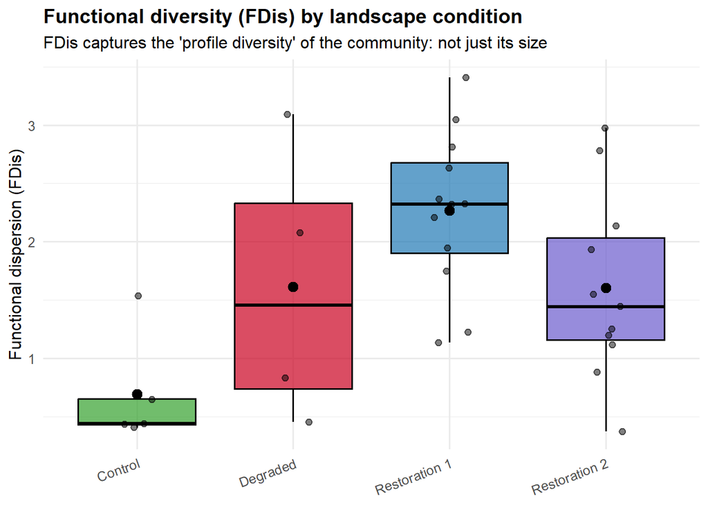

```r
dados$fdis <- fdis

ggplot(dados, aes(x = group, y = fdis, fill = group)) +
  geom_boxplot(alpha = 0.7, outlier.shape = NA, color = "black") +
  geom_jitter(width = 0.12, alpha = 0.5, size = 2) +
  stat_summary(fun = mean, geom = "point", size = 3, color = "black") +
  scale_fill_manual(values = c(
    "Control"       = "#33a02c",
    "Degraded"      = "#ca0020",
    "Restoration 1" = "#1f78b4",
    "Restoration 2" = "#6A5ACD"
  )) +
  theme_minimal(base_size = 12) +
  labs(
    title = "Functional diversity (FDis) by landscape condition",
    subtitle = "FDis captures the 'profile diversity' of the community: not just its size",
    x = NULL, y = "Functional dispersion (FDis)"
  ) +
  theme(legend.position = "none", plot.title = element_text(face = "bold"),
        axis.text.x = element_text(angle = 20, hjust = 1))
```

```r
anova_fdis <- aov(fdis ~ group, data = dados)
shapiro.test(residuals(anova_fdis))
```

```
##
##  Shapiro-Wilk normality test
##
## data:  residuals(anova_fdis)
## W = 0.96949, p-value = 0.4855
```

```r
bartlett.test(richness ~ group, data = dados)
```

```
##
##  Bartlett test of homogeneity of variances
##
## data:  richness by group
## Bartlett's K-squared = 6.2497, df = 3, p-value = 0.1001
```

```r
summary(anova_fdis)
```

```
##             Df Sum Sq Mean Sq F value  Pr(>F)
## group        3  9.035  3.0118   5.068 0.00627 **
## Residuals   28 16.640  0.5943
## ---
## Signif. codes:  0 '***' 0.001 '**' 0.01 '*' 0.05 '.' 0.1 ' ' 1
```

**Result:** Significant differences detected (p < 0.01).

## 6. Metric 3 — Community Composition (Structural Analysis)

PCoA (Principal Coordinates Analysis) is a dimensionality reduction technique, analogous to PCA, that maps community similarity in 2D space. Points closer together = more similar composition.

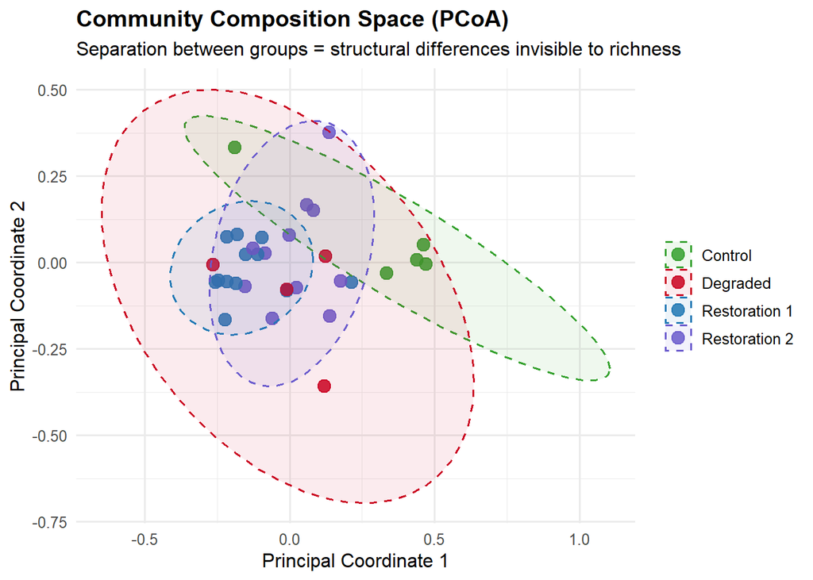

```r
dist_matrix <- vegdist(cmm_hell, method = "bray")
pcoa        <- cmdscale(dist_matrix, k = 2)

df_pcoa <- data.frame(
  Axis1 = pcoa[, 1],
  Axis2 = pcoa[, 2],
  group = dados$group
)

ggplot(df_pcoa, aes(Axis1, Axis2, color = group)) +
  geom_point(size = 3.5, alpha = 0.85) +
  stat_ellipse(aes(fill = group), geom = "polygon", alpha = 0.08, linetype = 2) +
  scale_color_manual(values = c(
    "Control"       = "#33a02c",
    "Degraded"      = "#ca0020",
    "Restoration 1" = "#1f78b4",
    "Restoration 2" = "#6A5ACD"
  )) +
  scale_fill_manual(values = c(
    "Control"       = "#33a02c",
    "Degraded"      = "#ca0020",
    "Restoration 1" = "#1f78b4",
    "Restoration 2" = "#6A5ACD"
  )) +
  theme_minimal(base_size = 12) +
  labs(
    title = "Community Composition Space (PCoA)",
    subtitle = "Separation between groups = structural differences invisible to richness",
    x = "Principal Coordinate 1", y = "Principal Coordinate 2",
    color = NULL, fill = NULL
  ) +
  theme(plot.title = element_text(face = "bold"))
```

## 7. Insights & Takeaways

### Finding 1 - The wrong KPI gives the wrong answer

[output not shown]

> **Data lesson:** A dashboard showing “no change” in a top-line metric may be hiding significant structural shifts. Always interrogate *what* you’re measuring, not just *whether* it changed.

### Finding 2 - Structure ≠ Volume

Two groups can have the same number of items (species, customers, transactions) while being entirely different in *composition*. Multivariate methods reveal this. Aggregate counts don’t.

> **Data lesson:** Segment-level structure analysis (clustering, PCA, PCoA) catches what KPI dashboards miss.

## Skills Demonstrated

*(AI generated based on the script)*

| Skill | Applied as |
| --- | --- |
| Data wrangling | tidyverse pipelines, matrix alignment, missing data handling |
| Feature engineering | Hellinger transformation, functional metrics (FDis) |
| Statistical testing | ANOVA with assumption checking (Shapiro, Bartlett) |
| Dimensionality reduction | PCoA / cmdscale on Bray-Curtis dissimilarity matrix |
| Data visualization | ggplot2 with layered geometries, ellipses, color encoding |
| Critical interpretation | Multi-metric framework, translating results to decisions |

*Gabriela Albuquerque Galvão · ggalvao96@gmail.com · Recife, PE*